# 02 playground

```r
library(tidyverse)

source('simfns.R')  # load simdat functions
```

# main running example for lec 2

latin square, condition fully crossed w ppts and w items

The story: masked priming, primed with a related word vs. when primed with a distractor

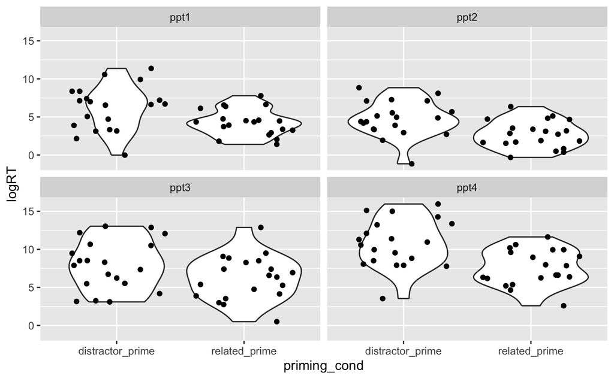

```r
n_ppts  <- 4
n_items <- 20

dat <- simcross(
  seed=1,
  b0=2,
  b1=1,  # wi_itms_wi_ppts
  b2=1,  # wi_ppts_btw_itms
  b3=2,  # x or xcat
  n_ppts=n_ppts, n_itms=n_items,
  n_obs_per=2
) |>
  select(ppts, itms, xcat, y) |>
  rename(
    ppt_id = ppts,
    item_id = itms,
    priming_cond = xcat,
    logRT = y
  ) |>
  mutate(
    priming_cond = ifelse(priming_cond == 'a', 'related_prime', 'distractor_prime'),
    ppt_id = paste0('ppt', ppt_id),
    item_id = paste0('item', item_id),
  )

dat |>
  ggplot(aes(x = priming_cond, y = logRT)) +
  geom_violin() +
  geom_jitter () +
  facet_wrap(~ ppt_id)
```

Identify grouping structure:

- we are looking only at categorical variables
- we want to see: what categorical variables have values that are associated with more than one data point?

```r
dat |> head()
```

|  | ppt_id | item_id | priming_cond | logRT |
| --- | --- | --- | --- | --- |
| 1 | ppt1 | item1 | related_prime | 3.255110 |
| 2 | ppt1 | item1 | distractor_prime | 5.056863 |
| 3 | ppt2 | item1 | related_prime | 1.839405 |
| 4 | ppt2 | item1 | distractor_prime | 3.342995 |
| 5 | ppt3 | item1 | related_prime | 6.942142 |
| 6 | ppt3 | item1 | distractor_prime | 8.523813 |

what cat vars do we have? (not including the outcome, if it’s binary) - ppt_id - item_id - priming_cond

we’ll go through each of these.

assuming data is set up for analysis using lm, with one column per variable and one row per observation, then we should just be able to count how many times each value shows up

```r
dat |>
  group_by(ppt_id) |>
  count()
```

| ppt_id | n |
| --- | --- |
| ppt1 | 40 |
| ppt2 | 40 |
| ppt3 | 40 |
| ppt4 | 40 |

can sense check by visually inspecting df. “ppt1” shows up with a bunch of different logRTs.

```r
dat |>
  group_by(item_id) |>
  count()
```

| item_id | n |
| --- | --- |
| item1 | 8 |
| item10 | 8 |
| item11 | 8 |
| item12 | 8 |
| item13 | 8 |
| item14 | 8 |
| item15 | 8 |
| item16 | 8 |
| item17 | 8 |
| item18 | 8 |

[output cut: 10 more lines]

each item also appears multiple times.

```r
dat |>
  group_by(priming_cond) |>
  count()
```

| priming_cond | n |
| --- | --- |
| distractor_prime | 80 |
| related_prime | 80 |

and each priming condition shows up multiple times.

So we have three groups that each contribute multiple data points:

- `ppt_id`
- `item_id`
- `priming_cond`

how do these groups relate to one another?

```r
dat |>
  group_by(ppt_id, item_id, priming_cond) |>
  count()
```

| ppt_id | item_id | priming_cond | n |
| --- | --- | --- | --- |
| ppt1 | item1 | distractor_prime | 1 |
| ppt1 | item1 | related_prime | 1 |
| ppt1 | item10 | distractor_prime | 1 |
| ppt1 | item10 | related_prime | 1 |
| ppt1 | item11 | distractor_prime | 1 |
| ppt1 | item11 | related_prime | 1 |
| ppt1 | item12 | distractor_prime | 1 |
| ppt1 | item12 | related_prime | 1 |
| ppt1 | item13 | distractor_prime | 1 |
| ppt1 | item13 | related_prime | 1 |

[output cut: 150 more lines]

each ppt sees each item twice, once in the distractor prime condition and once in the related prime condition.